# Week 1: Web data collection 1

SECU0050

Bennett Kleinberg

16 Jan 2020

Data Science for Crime Scientists

**What is this? and Why do we need it?**

## Aaah: so we’re talking Big Data!

[figure not shown]

## Problems with “Big Data”

- what is “big”?
- data = data?
- complexity of data?
- sexiness of small data

## Things you’ll do

- Accessing news article data and academic literature through APIs
- Building proper web-scrapers to collect data on the FBI’s most wanted terrorists
- Analysing patterns of language use in text data
- Utilising Natural Language Processing to understand controversial news coverage
- Identifying the semantic relationships of concepts through automated methods
- Building fake news and sentiment classification systems using machine learning
- Utilising clustering to identify patterns in YouTube videos
- Building neural networks for prediction tasks
- your own project

## Learning hours

| Component | Amount | Duration | Total hours |
| --- | --- | --- | --- |
| Lectures | 10 | 2h | 20h |
| Tutorials/practicals | 10 | 1h | 10h |
| Assessment: class test | 1 | 1h | 1h |
| Assessment: project | 1 | 47h | 47h |
| Homework/revision/self-study | 11 | 10h | 110h |
| TOTAL | - | - | 188h |

$\approx$ 17 hours per week

## Becoming a real problem-solver

- Principle 1: There’s no magic in Data Science
- Principle 2: Data never come in a spreadsheet
- Principle 3: Data are hidden in front of you
- Principle 4: Programming can only ever be the vehicle

It all starts with the data.

It all starts with a problem.

## Week 1: Web data collection 1

## Today

- Types of webscraping
- Using APIs
- “Real” webscraping: basics of a webpage

## What is webscraping anyway?

## The game changer!

- direct broadcasting of ideas
- “unfiltered” and “uncensored” (?)
- location-enabled
- and: *en masse*

## Types of webscraping

|  | Data shared | Data not shared |
| --- | --- | --- |
| Ready-made table | Download | *closed source* |
| Not ready-made | API | Real webscraping |

### Application programming interfaces (APIs)

## API: basics

Goal:

- helping developers interact with the platform
- facilitating interaction in an automatable manner
- analogous to the GUI
- part of it: enabling data access
- contains precise documentation

## What an API does not do:

- give you all the data
- be free forever
- give you full control

There’s no free lunch!

## Core elements of an API:

- GET requests
- POST requests

Implementable in different ways…

## Classes of APIs

1. Web APIs
   - send requests through the browser
   - add URL parameters `https://data.police.uk/api/crimes-at-location?date=2017-08&location_id=884227`
2. Libraries/packages for APIs
   - depending on the API: python, js, php, ruby
   - = frameworks to access the API
   - = methods implemented in different languages
3. API wrappers
   - R packages that use the API

## Useful websites that have an API

- Twitter (`twitteR`, `rtweet`)
- YouTube (`tuber`)
- Instagram
- Facebook
- Reddit
- The Guardian

**Recommended: try online tutorials**

## API Example 1: Newspaper coverage

Accessing TheGuardian data using [`GuardianR`](https://rdrr.io/cran/GuardianR/man/get_guardian.html)

```r
library(GuardianR)

get_guardian("SOME SEARCH TERM",
             from.date="START_DATE",
             to.date="END_DATE",
             api.key="YOUR_ACCESS_KEY")
```

## How to obtain the access key?

https://open-platform.theguardian.com/access/

[figure not shown]

## Step 1: sending API requests

Aim: search for keyword “crime” in Aug 2019

```r
request.crime = get_guardian("crime",
                             from.date="2019-08-01",
                             to.date="2019-08-31",
                             api.key="ea765...")
```

*Note: save these requests in an R object (variable)*

## Step 2: understanding the data

Dimensions (rows, columns) of the `request.crime` object

```r
dim(request.crime)
```

```
## [1] 430  27
```

## Column names

```r
names(request.crime)
```

```
##  [1] "id"                   "sectionId"            "sectionName"
##  [4] "webPublicationDate"   "webTitle"             "webUrl"
##  [7] "apiUrl"               "newspaperPageNumber"  "trailText"
## [10] "headline"             "showInRelatedContent" "lastModified"
## [13] "hasStoryPackage"      "score"                "standfirst"
## [16] "shortUrl"             "wordcount"            "commentable"
## [19] "allowUgc"             "isPremoderated"       "byline"
## [22] "publication"          "newspaperEditionDate" "shouldHideAdverts"
## [25] "liveBloggingNow"      "commentCloseDate"     "body"
```

## Displaying the data

| id | sectionName | webTitle | headline |
| --- | --- | --- | --- |
| books/2019/aug/07/top-10-true-books-duncan-campbell | Books | Top 10 true crime books | Top 10 true crime books |
| books/2019/aug/23/best-recent-crime-and-thrilers-review-roundup | Books | The best recent crime and thrillers – review roundup | The best recent crime and thrillers – review roundup |
| politics/2019/aug/12/boris-johnson-crime-crackdown-policing-prisons | Politics | Johnson’s crackdown on offenders will only entrench crime | Johnson’s crackdown on offenders will only entrench crime |
| commentisfree/2019/aug/12/boris-johnson-crime-fighting-crusade-posturing-brexit | Opinion | Boris Johnson’s ‘crime fighting’ crusade is mere posturing \| Simon Jenkins | Boris Johnson’s ‘crime fighting’ crusade is mere posturing |
| uk-news/2019/aug/05/rural-crime-in-britain-hits-seven-year-high | UK news | Rural crime in Britain hits seven-year high | Rural crime in Britain hits seven-year high |

## Displaying the data

|  | headline | wordcount | byline | newspaperEditionDate |
| --- | --- | --- | --- | --- |
| 11 | Surge in violent crime in Barcelona prompts calls for legal reform | 451 | Stephen Burgen in Barcelona | 2019-08-24T00:00:00Z |
| 12 | Monica Lewinsky to produce American Crime Story drama about Clinton scandal | 505 | Gwilym Mumford | 2019-08-08T00:00:00Z |
| 13 | Eric Cantona speech: humans ‘will become eternal’ â€“ unless crime or war intervene | 397 | Guardian sport | NA |
| 14 | 87 bird crime incidents last year and just one conviction, says RSPB | 388 | Patrick Barkham | 2019-08-29T00:00:00Z |
| 15 | Video of trans women forced from LA bar prompts hate crime investigation | 994 | Sam Levin in Los Angeles | NA |

## The article body

```r
as.character(request.crime$body[33])
```

```
## [1] "<p>The police minister, Kit Malthouse, has insisted that a new wave of stop-and-search operations should not increase community tensions as the government unveiled a series of anti-crime measures.</p> <p>Both Boris Johnson, the prime minister, and Priti Patel, the home secretary, announced i…
```

## Step 3: using the data

Note: not all sections are relevant (e.g., book reviews vs politics vs uk news)

Option 1: sending a new API request [(R package docs)](https://rdrr.io/cran/GuardianR/man/get_guardian.html)

```r
library(GuardianR)
request.crime.uknews = get_guardian("crime",
                                    from.date="2019-08-01",
                                    to.date="2019-08-31",
                                    section = 'uk-news',
                                    api.key="ea765...")
```

## “UK News” crime coverage

```r
dim(request.crime.uknews)
```

```
## [1] 32 27
```

| id | sectionName | webTitle | headline |
| --- | --- | --- | --- |
| uk-news/2019/aug/05/rural-crime-in-britain-hits-seven-year-high | UK news | Rural crime in Britain hits seven-year high | Rural crime in Britain hits seven-year high |
| uk-news/2019/aug/02/east-london-volunteers-set-up-knife-amnesty-bin | UK news | ‘There’s not enough police’: East London volunteers take on knife crime | ‘There’s not enough police’: East London volunteers take on knife crime |
| uk-news/2019/aug/08/female-knife-possession-crimes-in-england-rise-by-73 | UK news | Female knife possession crimes in England rise by 73% | Female knife possession crimes in England rise by 73% |
| uk-news/2019/aug/14/nca-freezes-more-than-100m-after-court-order-on-imported-money | UK news | NCA freezes £100m suspected to be from corruption overseas | NCA freezes £100m suspected to be from corruption overseas |
| uk-news/2019/aug/07/alesha-macphail-killer-appeals-against-27-year-sentence | UK news | Alesha MacPhail killer appeals against 27-year minimum sentence | Alesha MacPhail killer appeals against 27-year minimum sentence |

## Option 2: subsetting the data

```r
crime_data_uknews = request.crime[request.crime$sectionId == "uk-news", ]
dim(crime_data_uknews)
```

```
## [1] 32 27
```

## Step 3: Using the data

Aim: investigate article length

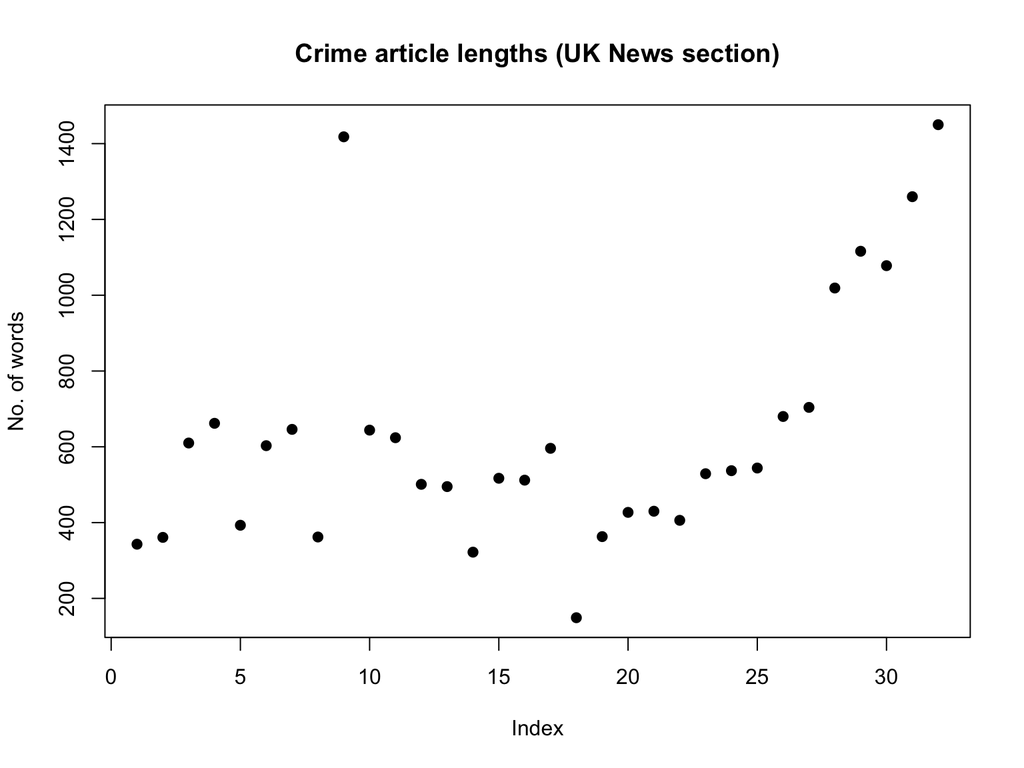

## … by author

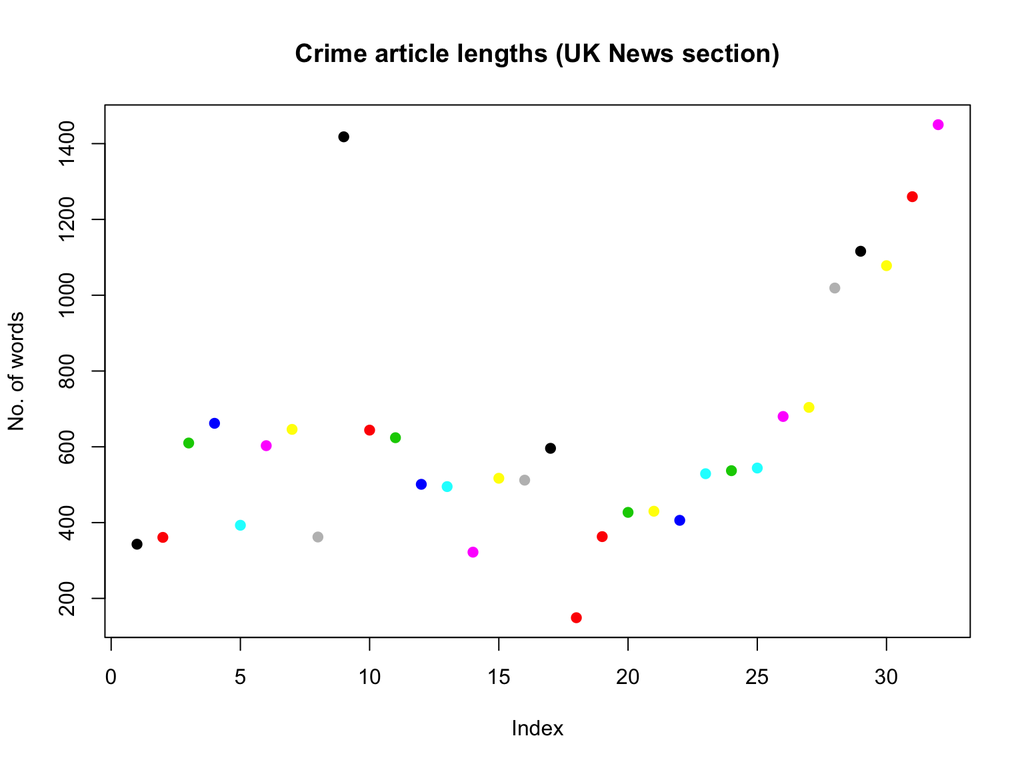

## Numerically

```r
tapply(X = as.numeric(as.character(request.crime.uknews$wordcount))
       , INDEX = request.crime.uknews$byline
       , FUN = mean)
```

```
##                                  Frances Perraudin
##                                              343.0
##                                         Amy Walker
##                                              362.0
##          Jamie Grierson Home affairs correspondent
##                                              573.5
##                  Rupert Neate Wealth correspondent
##                                              662.0
##                Libby Brooks Scotland correspondent
##                                              393.0
##                 Helen Pidd North of England editor
##                                             1026.5
##         Vikram Dodd Police and crime correspondent
##                                              862.0
##                                            Letters
##                                              362.0
##                                    Duncan Campbell
##                                             1418.0
##                                        Dan Sabbagh
##                                              644.0
##                    Severin Carrell Scotland editor
##                                              624.0
##    Rebecca Smithers Consumer affairs correspondent
##                                              501.0
##                                       Mattha Busby
##                                              512.0
##                                           PA Media
##                                              322.0
##       Josh Halliday North of England correspondent
##                                              473.5
##                   Mark Townsend and Michael Savage
##                                              512.0
## Maya Wolfe-Robinson North of England correspondent
##                                              596.0
##                                       Diane Taylor
##                                              704.5
##                           Steven Morris and agency
##                                              427.0
##                                     Georgina Hayes
##                                              406.0
##                        Latifa Yedroudji and agency
##                                              544.0
##                                       Simon Murphy
##                                              680.0
##                                      Mark Townsend
##                                              704.0
##                                          Ben Quinn
##                                             1019.0
##                                        Lucy Mangan
##                                             1116.0
```

## API Example 2: Academic literature

[figure not shown]

## Utilising the `aRxiv` package

- Docs: https://ropensci.org/tutorials/arxiv_tutorial/
- Repo: https://github.com/ropensci/aRxiv

## Sending queries

1. Author search with full data

```r
library(aRxiv)
arxiv_author_search = arxiv_search(query = 'au:"Hinrich Schuetze"'
                                   , limit=50)
```

| id | submitted | updated | title |
| --- | --- | --- | --- |
| cmp-lg/9503009v1 | 1995-03-08 18:36:40 | 1995-03-08 18:36:40 | Distributional Part-of-Speech Tagging |
| cmp-lg/9707002v1 | 1997-07-08 21:08:34 | 1997-07-08 21:08:34 | Automatic Detection of Text Genre |
| 1301.2811v3 | 2013-01-13 19:33:31 | 2013-04-26 12:33:50 | Cutting Recursive Autoencoder Trees |
| 1301.3627v2 | 2013-01-16 08:37:39 | 2013-05-11 12:17:44 | Two SVDs produce more focal deep learning representations |
| 1610.00479v3 | 2016-10-03 10:30:13 | 2017-05-01 14:30:00 | Nonsymbolic Text Representation |

## Sending queries

2. Author search with count data

```r
arxiv_count(query = 'au: Hinrich Schuetze')
```

```
## [1] 229
```

## Sending queries

3. Articles submitted by category and date

All articles in the “Computation & Language” subcategory submitted in the 1st of May 2019.

```r
arxiv_count(query = 'cat:cs.CL AND submittedDate:20190501*')
```

```
## [1] 10
```

## Sending queries

4. Articles submitted by category and date

Do NLP researchers work over the Christmas holidays?

What would the query need to look like?

```r
arxiv_count(query = 'cat:cs.CL AND submittedDate:[20191224* TO 20191231*]')
```

```r
arxiv_count(query = 'cat:cs.CL AND submittedDate:[20191224* TO 20191231*]')
```

```
## [1] 55
```

## APIs: Pros & Cons

**Pro**

- easy to access
- nicely documentation
- **works even if website changes**

**Cons**

- quota limits ($ $ $)
- under the platforms’ control
- only for few platforms

### Don’t let the data determine your research!

## Beyond APIs

What about:

[figure not shown]

## No APIs

- incels.me
- Stormfront
- 4chan
- **APIs are restrictive!**

## … what about:

### Your research project –> no API?

[figure not shown]

Main problem:

**Really ‘juicy’ data of the Internet** vs **APIs**

## “Real” webscraping: basics of a webpage

## Three elements of a webpage

1. Structure
2. Behaviour
3. Style

## Three elements of a webpage

1. Structure
2. Behaviour
   - JavaScript (**!= Java**)
   - user interaction
   - examples: alerts, popups, server-interaction
3. Style

## Three elements of a webpage

1. Structure
2. Behaviour
3. Style
   - CSS (Cascading Style Sheets)
   - formatting, design, responsiveness
   - examples: submit buttons, app interfaces

## Three elements of a webpage

1. Structure
   - HTML (hypertext markup language)
   - structured with `<tags>`
   - contains the pure content of the webpage
2. Behaviour
3. Style

## For now: HTML

The very basics of HTML:

**Raw architecture of a webpage**

```html
<!DOCTYPE html>
<html>
<body>

HERE COMES THE VISIBLE PART!!

</body>
</html>
```

*Note:* Every tags `< >` is closed `< />`. Content is contained within the tag.

## HTML basics

Ways to put content in the `<body> ... </body>` tag:

- headings: `<h1>I'm a heading at level 1</>`

[figure not shown]

## Content in the body tag

- paragraphs: `<p>This is a paragraph</p>`

[figure not shown]

## Content in the body tag

- images: `<img src="../img/ucl.jpg">`

[figure not shown]

## Content in the body tag

- links: `<a href="https://www.ucl.ac.uk/">Click here to go to UCL's website</a></a>`

[figure not shown]

## Web scraping logic

If all webpages are built in this structure…

… then we could access this structure programmatically.

## But where do I find that structure?

Is it just “there”?

**YES!!**

## How to see the html structure?

[figure not shown]

## Webscraping in a nutshell

1. understand the structure of a webpage
2. exploit that structure for web-scraping

## What’s next?

- Today’s tutorial: building your own API scraper, using the data, some HTML
- Homework: arxiv scraping, Twitter access, project start

Next week: Web scraping 2 (more HTML, browser simulation)